# Twitter and Zipf's Law

*Examining the application of Zipf's Law to Twitter*

[code](https://github.com/edz504/tweet-zipf)  
[me](https://github.com/edz504)

## Introduction

[Zipf's Law](http://en.wikipedia.org/wiki/Zipf's_law) is an empiral formulation that says many types of data can be approximated with a Zipfian distribution. This is commonly expressed as the idea that the frequency of any word in a corpus of natural language is inversely proportionally to its rank. In its most general and informal form, it is most easily observed by plotting the frequency rank of a given word against the actual count of that word on a log-log scale. The more linear this plot is, the stronger the adherence of the data to Zipf's Law.

Zipf's Law is most easily recognizable in large corpora -- for example, those included in the NLTK Python package.

```python
import numpy as np
import matplotlib.pyplot as plt
import pylab as pl
import nltk
from nltk.probability import FreqDist
import re, operator
from nltk.corpus import brown, reuters, nps_chat

def plotFdist(n, title=None, fdist=None):
    fsort_tuple = sorted(fdist.items(), key=operator.itemgetter(1),
        reverse=True)
    freqs_np_vals = np.array([t[1] for t in fsort_tuple])[0:n]
    freqs_np_words = np.array([t[0] for t in fsort_tuple])[0:n]

    pl.rcParams['figure.figsize'] = (20.0, 6.0)
    width = .35
    ind = np.arange(len(freqs_np_vals))
    plt.title(title)
    plt.bar(ind, freqs_np_vals)
    plt.xticks(ind + width / 2, freqs_np_words, rotation='vertical')
    plt.show()

def wordOnlyFDist(fdist):
    # only leave letters (does the rest count as "language"? tricky)
    word_only_keys = [k for k in fdist.keys() if re.search(r'^[a-zA-Z]+$',
        k)]
    return({ key : fdist[key] for key in word_only_keys })
```

```python
brown_fdist = FreqDist(w.lower() for w in brown.words())
reut_fdist = FreqDist(w.lower() for w in reuters.words())
nps_fdist = FreqDist(w.lower() for w in nps_chat.words())
```

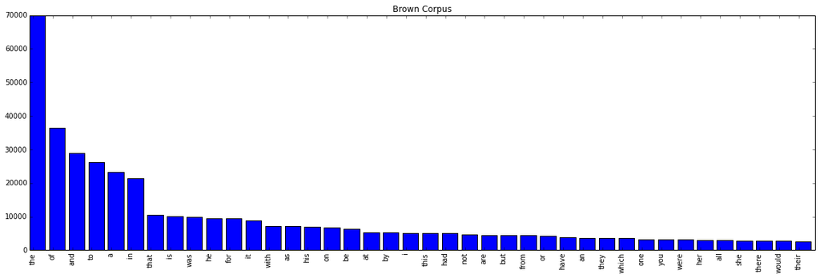

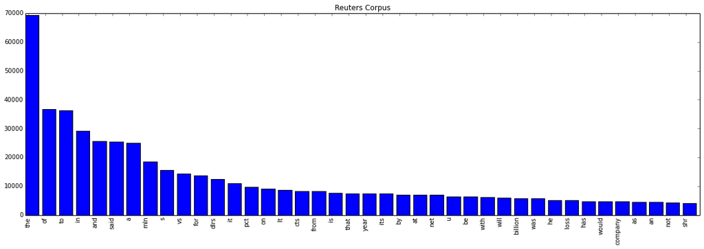

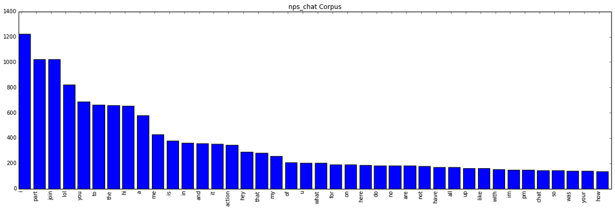

```python
NUM_PLOT = 40
%matplotlib inline
plotFdist(n=NUM_PLOT, title='Brown Corpus',
    fdist=wordOnlyFDist(brown_fdist))
plotFdist(n=NUM_PLOT, title='Reuters Corpus',
    fdist=wordOnlyFDist(reut_fdist))
plotFdist(n=NUM_PLOT, title='nps_chat Corpus',
    fdist=wordOnlyFDist(nps_fdist))
```

It loks like brown and reuters follow Zipf's quite well, whereas nps_chat maybe not as much. We can quantify the adherence, with a simple linear regression on the log-log scale:

```python
from scipy import stats

def zipfFit(fdist, name, toPlot=False, pr=False, ret=True):
    fsort_tuple = sorted(fdist.items(), key=operator.itemgetter(1),
    reverse=True)
    y_vals = np.array([t[1] for t in fsort_tuple])
    x_vals = np.array(range(1, len(y_vals) + 1))
    if toPlot:
        plt.title(name)
        pl.rcParams['figure.figsize'] = (5.0, 5.0)
        plt.plot([np.log(x) for x in x_vals],
            [np.log(y) for y in y_vals], 'ro')
        plt.xlabel('log(rank)')
        plt.ylabel('log(count)')
        plt.show()
    slope, intercept, r_value, p_value, std_err = stats.linregress(
        np.log(x_vals.astype(float)),
        np.log(y_vals.astype(float)))
    if pr:
        print "log-log r-squared for " + name + ":", r_value**2
    if ret:
        return([slope, intercept, r_value**2])
```

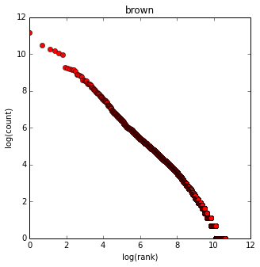

```
log-log r-squared for brown: 0.971412066095
```

```python
zipfFit(wordOnlyFDist(brown_fdist), 'brown', toPlot=True, pr=True, ret=False)
```

```python
zipfFit(wordOnlyFDist(reut_fdist), 'reuters', pr=True, ret=False)
zipfFit(wordOnlyFDist(nps_fdist), 'nps_chat', pr=True, ret=False)
```

```
log-log r-squared for reuters: 0.977601127158
log-log r-squared for nps_chat: 0.961693866368
```

The corpora used here are standard natural language collections, so their adherence to Zipf's Law is nothing new. The questions we want to ask include the following:  
* Does a single user's collection of tweets follow Zipf's Law (perhaps that user has his/her own "language")? What makes certain users follow Zipf's Law more than others? * Does a geographically grouped collection of tweets follow Zipf's Law (local lingo?)

Luckily, Twitter provides a RESTful API that allows us to access (in a limited fashion) Twitter users and their tweets.

## Setting up the Twitter API

We'll be working with the [twitter Python package](https://pypi.python.org/pypi/twitter), which enables us to access the [Twitter API](https://dev.twitter.com/docs) after obtaining proper authorization from [creating a new Twitter application](https://apps.twitter.com/). Extracting the consumer key, consumer secret, access token key, and access token secret (whatever each of those means) into a text document keeps our code is viewable without giving everyone access to our Twitter account. `twitter_api.txt` simply has each authentication item on a separate line. Then, we can do the following:

```python
import twitter
mine = [s.strip() for s in open('twitter_api.txt', 'rb').readlines()]
twitter_api = twitter.Api(
    consumer_key=mine[0],
    consumer_secret=mine[1],
    access_token_key=mine[2],
    access_token_secret=mine[3])
```

We can use the API to pull out users:

```python
snames = ['edz504', 'perezhilton']
users = twitter_api.UsersLookup(screen_name = snames)
[u.statuses_count for u in users]
```

```
[820, 222814]
```

and pull out a maximum of 200 tweets (per request) from a given user's timeline:

```python
this_user_tweets = twitter_api.GetUserTimeline(screen_name='perezhilton', count=200)
```

## Retrieving and Cleaning Tweets

We can pull out up to about 3200 tweets from a given user by repeatedly specifiying a `max_id` parameter. This method roughly pulls in 200 per request, but Twitter does not fill holes in status ids, so if a user has deleted tweets, a given request may only turn up 195 tweets or similar (print commented out):

```python
def getUserTweets(u):
    if (u.statuses_count < 1 or u.protected): # don't bother going through if we know the user doesn't have any tweets
        # or if they're protected
        return([])
    else:
        user_tweets = []
        keep_em_coming = True

        while (keep_em_coming):
            # for our first time, no max_id
            if len(user_tweets) == 0:
                this_user_tweets = twitter_api.GetUserTimeline(
                    screen_name=u.screen_name,
                    count=200)
            else:
                this_user_tweets = twitter_api.GetUserTimeline(
                    screen_name=u.screen_name,
                    count=200,
                    max_id=oldest_id)
            # print 'Pulled in ' + str(len(this_user_tweets)) + ' new tweets'
            if len(this_user_tweets) <= 1:
                keep_em_coming = False
            else:
                oldest_id = min([t.id for t in this_user_tweets])
            user_tweets += this_user_tweets
        return(user_tweets)
```

Each status object has a `.text` field that has the data we want. Since we'll be forming corpora from a set of tweets, and analyzing word frequencies from those corpora, we'll want to clean the tweets. The method of cleaning we employ here is slightly arbitrary -- since we don't believe screen names count as words, we filter those out:

```python
import re

def remove_sn(t):
    rep = 0
    ats_cleaned = True
    if ('@' in t):
        ats_cleaned = False
    while(not ats_cleaned):
        at_ind_start = t.index('@')
        # any non-screen-name-enabled character
        # so if the tweet is "...@Beyonce:blahhh "
        # then we leave blahhh in the string too
        m = re.search(r'\W', t[at_ind_start + 1:])
        if m:
            at_ind_end = at_ind_start + m.start()
        else:
            at_ind_end = at_ind_start + len(t[at_ind_start:])
        t = t[:at_ind_start] + t[at_ind_end + 1:]
        if (not '@' in t):
            ats_cleaned = True
        if (rep > 140):
            print 'Reached' + str(rep) + ' repetitions for the string:'
            print t
            print 'at index ' + rep + 'breaking'
            break
        rep += 1
    return(t)
```

We also filter our URLs and all punctuation (excluding apostrophes and dashes). Note that this takes out the pound sign in a hashtag, leaving the actual content of the hashtag -- we're making the judgement call to keep that as a word.

```python
def remove_urls(t):
    urls = re.findall(r'http[s]?://(?:[a-zA-Z]|[0-9]|[$-_@.&+]|[!*\(\),]|(?:%[0-9a-fA-F][0-9a-fA-F]))+', t)
    for url in urls:
        t = re.sub(re.escape(url), '', t)
    return(t)

def leave_alphanumeric(t):
    return re.sub(r'(?! )(?!-)(?!\')\W', '', t)
```

Now we want to use the [nltk](http://www.nltk.org/) package to tokenize and assemble a frequency dictionary from a set of tweets.

```python
import nltk

# supply either a screen name, or a list of tweets
def getUserTweetWordFreqDist(u, user_tweets=None):
    if user_tweets is None:
        user_tweets = getUserTweets(u)
    user_tweets_str = [t.text.encode('utf-8') for t in user_tweets]
    user_tweets_clean1 = [remove_sn(t_str1) for t_str1 in user_tweets_str]
    user_tweets_clean2 = [remove_urls(t_str2) for t_str2 in user_tweets_clean1]
    user_tweets_clean3 = [leave_alphanumeric(t_str3) for t_str3 in user_tweets_clean2]
    user_tweets_collapse = ''.join(user_tweets_clean3)
    user_tweets_tokens = nltk.word_tokenize(user_tweets_collapse)

    fdist = FreqDist(word.lower() for word in user_tweets_tokens)
    return(fdist)
```

## Aggregating "Random" Users

The first question we want to answer is if individual users have their own "language" -- specifically, whether or not their language adheres to Zipf's Law. That is, we want to know if assembling their tweets into a corpus and doing frequency analysis results in any level of adherence to Zipf's Law. Before we can do this, we have to assemble a set of users.

Since Twitter users can be queried by a `user_id`, which is always some integer, we use the `UsersLookup` call from the Twitter API and random integers to aggregate a set of users. Twitter has made it clear that their system of `user_id`'s is not uniform -- people have reported consecutive `user_id`'s in a row for a certain integer range, and jumps of 10 in a different range. For now, we simply use `randint` to obtain some random integer between 1 and `sys.maxint` and see if it matches to a user. Note we're also storing a list of users using Python's pickle package.

```python
import pickle

while (len(users) < 10000):
    uids = [randint(1, sys.maxint) for i in range(1, 100)]
    try:
        these_users = twitter_api.UsersLookup(user_id=uids)
    except Exception, e:
        d = ast.literal_eval(str(e))[0]
        error_code = d['code']
        if (error_code == 88):
            print d['message']
            rl_stat = twitter_api.GetRateLimitStatus()
            user_lookup_stat = rl_stat['resources']['users']['/users/lookup']
            remaining = user_lookup_stat['remaining']
            epoch_time = user_lookup_stat['reset']
            dt_reset = datetime.datetime.fromtimestamp(epoch_time
                ).strftime('%Y-%m-%d %H:%M:%S')
            print str(remaining) + ' tweets left.  Try again at ' + str(dt_reset)
            break
        else:
            print 'Error: ' + d['message']
            continue
    users += these_users
    print(len(users))
pickle.dump(users, open('users1.p', 'wb'))
```

Note the use of rate limiting -- Twitter only allows for a certain number of requests for a given call in a given 15 minute window. Since we are not aggregating a massive number of users (for now), we'll leave off on automating a 15-minute rest and retry implementation for later.

## Zipfian Fits by User

Let's see how we might visualize a user's "corpus" similar to how we visualized the NLTK corpora.

```python
def plotUserTopNWords(n, u=None, title=None, fdist=None):
    if title is None and (u is not None):
        title = u.screen_name
    if fdist is None and (u is not None):
        print 'Getting tweets for ' + u.screen_name
        fdist = getUserTweetWordFreqDist(u)
    fsort_tuple = sorted(fdist.items(), key=operator.itemgetter(1),
        reverse=True)
    freqs_np_vals = np.array([t[1] for t in fsort_tuple])[0:n]
    freqs_np_words = np.array([t[0] for t in fsort_tuple])[0:n]
    width = .35
    ind = np.arange(len(freqs_np_vals))
    plt.title(title)
    plt.bar(ind, freqs_np_vals)
    plt.xticks(ind + width / 2, freqs_np_words, rotation='vertical')
    pl.rcParams['figure.figsize'] = (20.0, 6.0)
    plt.show()
```

```
Getting tweets for PerezHilton
```

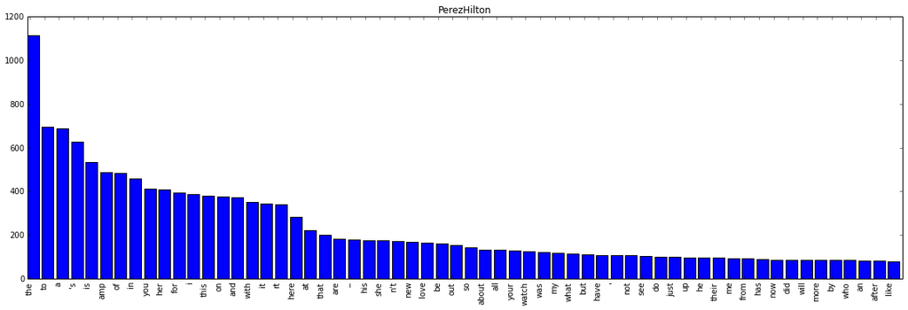

```python
ph = twitter_api.GetUser(screen_name='perezhilton')
NUM_PLOT = 60
plotUserTopNWords(u=ph,
    n=NUM_PLOT)
```

We can also apply the quantitative measure of Zipfian adherence (as we did for the other corpora):

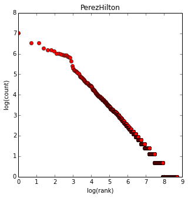

```
log-log r-squared for PerezHilton: 0.968095978803
```

```python
fdist = getUserTweetWordFreqDist(ph)
zipfFit(wordOnlyFDist(fdist), ph.screen_name, toPlot=True, pr=True, ret=False)
```

For those that are wondering, my go-to user is Perez Hilton not because we condone anything that comes from that Twitter account, but that we're sure to hit the API-imposed max of around 3200 tweets when we pull from his account -- some quick research shows that he has one of the highest `.statuses_count`'s in Twitter's userbase.

Now, we can go through all of the users that we aggregated in the previous section and apply a Zipfian fit. To leave us an open door for analysis, our pandas dataframe will also include various information about each user (one row = data for one user) that might provide insight as to why certain users' "languages" adhere to Zipf's more or less.

```python
import pandas as pd

users = pickle.load(open('users1.p', 'rb'))

# we only want users that have tweeted at least X times
NUM_TWEET_CUTOFF = 1
lang_users = [u for u in users if u.statuses_count > NUM_TWEET_CUTOFF]
# also, filter out protected peeps
end_users = [u for u in lang_users if not u.protected]
col = [
    'num_fit', 'r_squared', 'slope', 'intercept', 'statuses_count',
    'followers_count', 'following_count', 'age_days',
    'favourites_count', 'location', 'verified'
]
df = pd.DataFrame(index=[u.screen_name for u in end_users],
    columns=col)
df['statuses_count'] = [u.statuses_count for u in end_users]
df['followers_count'] = [u.followers_count for u in end_users]
df['following_count'] = [u.friends_count for u in end_users]
df['favourites_count'] = [u.favourites_count for u in end_users]
df['location'] = [u.location for u in end_users]
df['verified'] = [u.verified for u in end_users]
```

Another column that requires some more though is the age (in days). We can calculate this using `pytz` and an epoch that we look up. A [news article](http://www.usatoday.com/story/tech/2014/03/20/twitter-eighth-birthday-first-tweet/6646493/) says that March 21st, 2006 is the date of the oldest tweet.

```python
import pytz
from dateutil import parser
import time
epoch = parser.parse("Mar 21 2006 13:33:00").replace(tzinfo=pytz.UTC)
df['age_days'] = [(parser.parse(u.created_at) - epoch).days for u in end_users]
```

Now, we can cycle through our users and apply a Zipfian fit on each of them. Since we would be making up to 16 requests per user (~200 in a request, ~3200 max) and we want to go through all of the users in our `end_users` list, now is a good time to implement a rest-and-retry exception catch.

```python
i = 0
STOPPED = i

for u in end_users[STOPPED:]:
    # get as many tweets as possible for that user, assembling the tweets
    # into a corpus, clean and create an fdist
    try:
        # the getUserTweetWordFreqDist can retrieve the tweets on its own,
        # but we also want to see how many tweets we use for the fit
        tweets = tweet_retriever.getUserTweets(u)
        fdist = tweet_retriever.getUserTweetWordFreqDist(u, tweets)
    except Exception, e:
        d = ast.literal_eval(str(e))[0]
        error_code = d['code']
        if (error_code == 88):
            print d['message']
        print 'Currently, u = ' + u.screen_name + ', i = ' + str(i)
        STOPPED = i
        # break
        pickle.dump([STOPPED, df], open('zipf_fit_df.p', 'wb')) # save to pickle
        print 'Pausing for 15 minutes...'
        time.sleep(5 * 60)
        print '.'
        time.sleep(5 * 60)
        print '.'
        time.sleep(5 * 60)
        print 'Re-finding tweets'
        tweets = tweet_retriever.getUserTweets(u)
        fdist = tweet_retriever.getUserTweetWordFreqDist(u, tweets)
    fdist_wordsOnly = wordOnlyFDist(fdist)
    # fit the fdist to Zipf's
    slope, intercept, r_squared = zipfFit(fdist_wordsOnly,
        u.screen_name)
    # record stats
    df['num_fit'][i] = len(set(tweets))
    df['r_squared'][i] = r_squared
    df['slope'][i] = slope
    df['intercept'][i] = intercept
    i += 1
    print 'Finished <' + u.screen_name + '>'
```

This process isn't fully automated -- for some reason, even when a user is not protected and has more than 1 tweet, we still get an authorization error, or sometimes, and HttpRequest error because we could not establish the connection to Twitter. The process of fitting has taken several days due to the unclear authorization and other errors ("Page doesn't exist" despite the user existing), and despite our best attempts to automate the whole process.

## Which Users Fit Zipf's?

When we finish fitting all of the users, we can apply some analysis to the results. First, a brief look with `head()` and `describe()`

```python
import pickle
[STOPPED, df] = pickle.load(open('zipf_fit_df.p', 'rb'))
print df.head()
```

```
               num_fit  r_squared      slope intercept  statuses_count  \
JimLeavy1          137  0.9197579 -0.6354987   3.81751             136
Echelljoyot       3188  0.9393774 -0.8778004  6.569782           55247
gonzaga_ariane     263  0.8952295 -0.6966629  4.406337             268
man_chester          8          0          0         0               7
woanerjez            7  0.8262034 -0.4565467  1.289251               6

                followers_count  following_count  age_days  favourites_count  \
JimLeavy1                     9              200      2298                 4
Echelljoyot                1138              736      2493             15938
gonzaga_ariane              185              870      2565               395
man_chester                   1                2      1546                 0
woanerjez                     0               22      2735                 9

                        location verified
JimLeavy1                           False
Echelljoyot     Ukraine. Donetsk    False
gonzaga_ariane      *-Curitiba-*    False
man_chester                         False
woanerjez                           False
```

We should check how Pandas stored our columns to make sure we can describe and later operate on them -- to use `describe()` we can't have strings or objects.

```python
print df.dtypes
```

```
num_fit             object
r_squared           object
slope               object
intercept           object
statuses_count       int64
followers_count      int64
following_count      int64
age_days             int64
favourites_count     int64
location            object
verified              bool
dtype: object
```

```python
print df.drop('location', axis=1).astype(float).describe()
```

```
           num_fit    r_squared        slope    intercept  statuses_count  \
count  4120.000000  3943.000000  3811.000000  3811.000000     4132.000000
mean    385.114320     0.734823    -0.567406     2.756537      982.038238
std     860.222534     0.260034     0.357300     2.158494     4588.124964
min       0.000000     0.000000    -4.857981     0.000000        2.000000
25%       5.000000     0.698197    -0.730870     1.142783        4.000000
50%      19.000000     0.830437    -0.524251     2.031523       19.000000
75%     169.250000     0.896254    -0.372172     3.931391      173.250000
max    3266.000000     1.000000     0.000000    11.372158    84261.000000

       followers_count  following_count     age_days  favourites_count  \
count      4132.000000      4132.000000  4132.000000       4132.000000
mean        333.686834       142.001210  2090.954985        139.371491
std       14081.129429       412.433629   473.486975       1082.088202
min           0.000000         0.000000   400.000000          0.000000
25%           2.000000         8.000000  1775.000000          0.000000
50%          10.000000        33.000000  2170.500000          0.000000
75%          51.000000       137.000000  2482.000000          5.000000
max      903711.000000     17974.000000  2771.000000      42174.000000

          verified
count  4132.000000
mean      0.000726
std       0.026939
min       0.000000
25%       0.000000
50%       0.000000
75%       0.000000
max       1.000000
```

Looking at our summary here, it's clear that there are some `r_squared` values that are very good. Apparently, some users' tweet-corpora adhere to Zipf's Law even better than the Brown and Reuters corpus -- this partially answers our first question. The next question to ask now is why do some users adhere better to Zipf's Law? We can visualize this by plotting one of our features against the associated `r_squared` values.

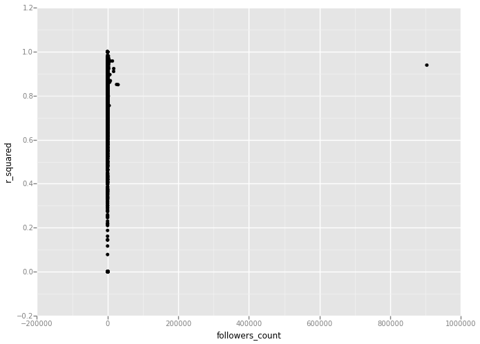

```python
from ggplot import *
%matplotlib inline
print ggplot(df, aes(x='followers_count', y='r_squared')) + geom_point()
```

That's not too helpful because of the one user with almost a million followers. For visualization purposes, let's see what this plot looks like without that point (and note that that user has a very tight adherence to Zipf's Law).

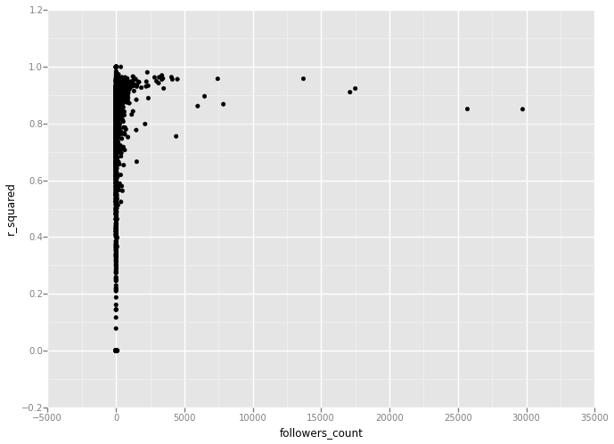

```python
df_quant = df[['num_fit', 'r_squared', 'slope',
    'intercept', 'statuses_count', 'followers_count',
    'following_count', 'age_days', 'favourites_count']].astype(float)
df_clean = df_quant.dropna()

df_vis = df_clean.loc[df_clean.index != df['followers_count'].argmax()]
print ggplot(df_vis, aes(x='followers_count', y='r_squared')) + geom_point()
```

The plot is a little more spread out, although there are an unfortunately large number of users with very few followers. As a side observation, though, we see that there are no users with more than 2500 followers whose Zipf-adherence is less than 0.75. This suggests that users with more followers are more likely to have a more "natural" language. This might be because there must be a reason users have more followers -- they embody some idea or show some sort of pattern that people (or a select subset of people) are drawn to, and so that may manifest as a "natural" language.

To quantify the question "What features can help us potentially **classify** users into those that do exhibit a language that may be natural, and those that do not?" we can define a cut-off value for the `r_squared` where users above the cut count as "good fits" and those below do not. Pulling from our previous corpora fits, we set this value to 0.95 (note: this is by no means an empirically derived number -- labeling particular ranges of R-squared values as "good" is never very valid, so we base our judgement on the R-squared returned by the existing corpora that we expect to follow Zipf's).

```python
ZCUT = 0.95
df_fit = df[df.r_squared >= ZCUT]
df_nfit = df[df.r_squared < ZCUT]
```

```python
pd.set_option('expand_frame_repr', False)
print df_fit.describe()
print df_nfit.describe()
```

```
       statuses_count  followers_count  following_count     age_days  favourites_count   verified
count      128.000000       128.000000       128.000000   128.000000        128.000000        128
mean      4596.593750       590.039062       353.109375  1972.804688        835.171875   0.015625
std      10871.236237      1597.949052       641.088189   562.265833       4216.005019  0.1245069
min          2.000000         0.000000         0.000000   629.000000          0.000000      False
25%         71.000000         6.000000        16.000000  1519.000000          0.000000          0
50%        869.000000       103.000000       106.000000  2065.500000          2.500000          0
75%       3521.750000       355.250000       375.250000  2450.000000         46.000000          0
max      69048.000000     13706.000000      4759.000000  2767.000000      42174.000000       True
       statuses_count  followers_count  following_count     age_days  favourites_count      verified
count     3815.000000      3815.000000      3815.000000  3815.000000       3815.000000          3815
mean       892.432241       340.167497       138.144954  2085.202621        122.008650  0.0002621232
std       4225.360962     14651.427306       404.261293   472.397585        810.904964    0.01619022
min          2.000000         0.000000         0.000000   400.000000          0.000000         False
25%          5.000000         2.000000         9.000000  1765.500000          0.000000             0
50%         19.000000        10.000000        35.000000  2166.000000          0.000000             0
75%        163.500000        50.000000       141.000000  2475.000000          5.000000             0
max      84261.000000    903711.000000     17974.000000  2771.000000      21662.000000          True
```

Just from looking at these two summaries, we think that certain features we collected might be useful in showing why some users fit Zipf's better -- those who fit well, for example, have a significantly higher `favourites_count`, and a `followers_count` (as seen earlier in the visualization). To visualize this difference again, we can plot a confidence interval for the `df_fit` and `df_nfit` `statuses_count` features.

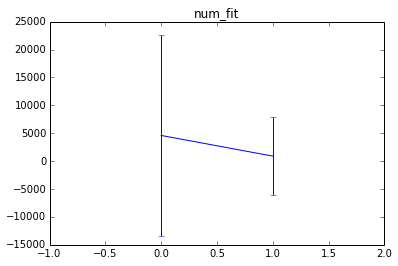

```python
import scipy.stats as ss

data_m = np.array([df_fit.describe().loc['mean'][0],
    df_nfit.describe().loc['mean'][0]])
data_df = np.array([df_fit.describe().loc['count'][0] - 1,
    df_nfit.describe().loc['count'][0] - 1])
data_sd = np.array([df_fit.describe().loc['std'][0],
    df_nfit.describe().loc['std'][0]])
plt.errorbar([0, 1], data_m, yerr=ss.t.ppf(0.95, data_df)*data_sd)
plt.xlim((-1,2))
plt.title(df_fit.columns[0])
plt.show()
```

A way of attempting to quantify how important these features are is to build a classifier. Note that this is slightly unintuitive, because in general we build a supervised classifier to classify new data, whereas the motivation here is to see how the various machine learning algorithms weight the different features in the classification. This isn't necessarily to say that we cannot classify new data (users) into "fits Zipf's" vs. "does not fit Zipf's", it's simply less meaningful because our true labels are defined by the limit we set at `ZCUT`.

```python
X = df_clean.drop(['r_squared', 'slope', 'intercept'], axis=1)
y = df_clean.r_squared >= ZCUT
```

After setting up the `X` and `y` dataframes/arrays, we can use Python's `scikit-learn` package to do a straightforward logistic regression. We print the training accuracy to make sure that the classifier is somewhat valid, and then print the coefficients that the classifier finished with.

```python
from sklearn import linear_model
est = linear_model.LogisticRegression()
est.fit(X, y)

train_pred = est.predict(X)
train_error = sum(train_pred ^ y) / float(len(y))

print 'Training Accuracy: ' + str(1 - train_error)
weights = pd.DataFrame(index=X.columns)
weights['val'] = est.coef_[0]
print weights
```

```
Training Accuracy: 0.966675413277
                       val
num_fit           0.000632
statuses_count   -0.000003
followers_count  -0.000002
following_count   0.000074
age_days         -0.000511
favourites_count  0.000058
```

As a final look at individual users, we can also use a SVM classifier instead of a logistic regression. If we use a linear kernel, we can also extract the weights that the algorithm gives and see if other features also play a large role in the algorithm's classification.

```python
from sklearn import svm
# do svm with linear kernel to find weights of features so we can
# see what is useful in seeing what users have Zipfian fits
est2 = svm.SVC(kernel='linear')
est2.fit(X, y)

pickle.dump([est, est2], open('classifiers.p', 'wb'))
```

```python
[est, est2] = pickle.load(open('classifiers.p', 'rb'))
train_pred2 = est2.predict(X)
train_error2 = sum(train_pred2 ^ y) / float(len(y))

weights2 = pd.DataFrame(index=X.columns)
weights2['val'] = est2.coef_[0]
print weights2
```

```
                       val
num_fit          -0.004607
statuses_count   -0.003910
followers_count   0.000131
following_count   0.000021
age_days         -0.000251
favourites_count  0.000773
```

The SVM classifier (which took ages) turned out weights that were a little different from the logistic regression, but again, the features it weighted more heavily make sense. `num_fit` and `statuses_count` actually both should be very correlated themselves, as `num_fit` is simply `statuses_count` maxed out at ~3200, and accounting for holes in Twitter's data.

## Local Lingo

Now we turn out attention to groups of tweets, rather than individuals' corpora. We want to answer our second question of whether or not a group of geographically grouped tweets (pulled not from the same user, but from the same geographic area) might follow Zipf's Law. We can also see if expanding the radius of the area considered increases or decreases the Zipfian adherence.

We'll look at the 250 most populous cities in America (source - Wikipedia), using BeautifulSoup to scrape the Wikipedia table. Check out our NBA Payroll Skew Analysis for a more complicated (and frustrating) scraping. Thank god Wikipedia keeps their HTML clean. We'll also be using the `tweepy` package this time, both for variety, and because the `python-twitter` package does not have a functional geocoding query.

```python
import tweepy

mine = [s.strip() for s in open('twitter_api.txt', 'rb').readlines()]
# OAuth process, using the keys and tokens
auth = tweepy.OAuthHandler(mine[0], mine[1])
auth.set_access_token(mine[2], mine[3])

# Creation of the actual interface, using authentication
api = tweepy.API(auth)

import requests
from bs4 import BeautifulSoup

url = 'http://en.wikipedia.org/wiki/List_of_United_States_cities_by_population'
r = requests.get(url)
soup = BeautifulSoup(r.text)
```

The basic idea here is to create a search in the `soup` object that can give us the table cells we need. We set up a Pandas dataframe to handle the extracted data (note: we also track population density, as we have a sneaking suspicion that may be relevant).

```python
def is_table_row(tag):
    return tag.name == 'tr' and (tag.td is not None) and \
    (tag.td.string in [str(i) for i in range(1, 251)])

rows = soup.findAll(is_table_row)
ranks = [tr.td.string for tr in rows]

rows = rows[:-5] # to get rid of Puerto Rican cities

def is_cell(tag):
    return tag.name == 'td'

cells = rows[0].findAll(is_cell)

import re
def clean_name(s):
    return re.sub(r'(?!\s)\W|[0-9]', '', s)

import pandas as pd
col = ['sq_mi', 'pop_dens', 'lat', 'lng']
df = pd.DataFrame(index=[clean_name(r.findAll(is_cell)[1].text) + ", " + \
    clean_name(r.findAll(is_cell)[2].text) for r in rows],
    columns=col)
```

Now, pulling out the data from within each cell requires some finagling of Unicode/UTF-8, but it's nothing we can't handle:

```python
# parse out square miles
sq_mi_list = []
dens_list = []
lat_list = []
lng_list = []
# I CLEANED OUT ALL THE NEGATIVE SIGNS
for r in rows:
    cell = r.findAll(is_cell)[6]
    str_sq_mi = cell.span.string.next
    sq_mi = float(re.sub(r'(?!\.)\W', '',  str_sq_mi.encode('utf-8'))[0:-4])
    sq_mi_list.append(sq_mi)

    cell = r.findAll(is_cell)[7]
    str_pop_dens = cell.span.string.next
    pop_dens = float(re.sub(r'(?!\.)\W', '',  str_pop_dens.encode('utf-8'))[0:-7])
    dens_list.append(pop_dens)

    cell = r.findAll(is_cell)[8]
    str_latlng = re.sub(r'(?!\.)(?!\s)\W', '', cell.string.encode('utf-8'))
    lat_list.append(float(str_latlng.split(' ')[0][0:-1])) #spot the N
    lng_list.append(-float(str_latlng.split(' ')[1][0:-1])) # and the W
df['sq_mi'] = sq_mi_list
df['pop_dens'] = dens_list
df['lat'] = lat_list
df['lng'] = lng_list
```

```python
print df.head()
```

```
                            sq_mi  pop_dens      lat       lng
New York, New York          302.6     27012  40.6643  -73.9385
Los Angeles, California     468.7      8092  34.0194 -118.4108
Chicago, Illinois           227.6     11842  41.8376  -87.6818
Houston, Texas              599.6      3501  29.7805  -95.3863
Philadelphia, Pennsylvania  134.1     11379  40.0094  -75.1333
```

Home is where the heart (and the curiosity) is, so we're also adding Princeton and Palo Alto to our dataframe.

```python
# adding Princeton and Palo Alto by hand <3
df.loc['Princeton, New Jersey'] = [17.933, 1600, 40.357830, -74.667396]
df.loc['Palo Alto, California'] = [23.884, 2500, 37.442494, -122.142961]
```

The last thing we need to do before starting the Twitter mining is to construct two new columns -- the geocode radius and the geocode query itself. Since we pulled out the square miles for each city, and Twitter's geocode parameter is in the form `geocode="<LAT>,<LNG>,<RAD>mi"`, we make the assumption that all city boundaries are circular (obviously a tenuous assumption at best), and calculate the radius with some simple geometry. We also account for suburbian areas, with data from [here](http://project.wnyc.org/commute-times-us/embed.html#5.00/42.000/-89.500) and [here](http://nhts.ornl.gov/briefs/Commuting%20for%20Life.pdf). That gives us the calculation (26.9 mi) / hr * (25.4 min) * (1 hour / 60 min) = 11.387 miles, so we tack that on to all of the radii. Finally, we also add the query column, following the prescribed format above.

```python
import numpy as np
# calculating radius from square miles (obviously approximation)
df['rad'] = np.sqrt(df['sq_mi'] / 2)
df['rad'] = df['rad'] + 26.9 * 25.4 / 60

df['geocode_query'] = [str(df['lat'][i]) + "," + str(df['lng'][i]) + \
"," + str(df['rad'][i]) + "mi" for i in range(0, df.shape[0])]
```

```python
import pickle
print df.tail()
pickle.dump(df, open('location_df.p', 'wb'))
```

```
                            sq_mi  pop_dens        lat         lng        rad  \
Manchester, New Hampshire  33.100      3310  42.984700  -71.443900  15.455836
Elgin, Illinois            37.200      2911  42.039600  -88.321700  15.700438
West Jordan, Utah          32.500      3195  40.602300 -112.001000  15.418796
Princeton, New Jersey      17.933      1600  40.357830  -74.667396  14.382078
Palo Alto, California      23.884      2500  37.442494 -122.142961  14.843387

                                                   geocode_query
Manchester, New Hampshire        42.9847,-71.4439,15.455835788mi
Elgin, Illinois                 42.0396,-88.3217,15.7004383972mi
West Jordan, Utah               40.6023,-112.001,15.4187955408mi
Princeton, New Jersey         40.35783,-74.667396,14.382078128mi
Palo Alto, California      37.442494,-122.142961,14.8433865627mi
```

Now, we can start aggregating the tweets by location in a similar fashion to our aggregation of tweets by user. Because some cities have so many tweets (while strangely, some others have very few), we have to move the sleep work-around to inside the by-city aggegation function `get_geo_tweets`, rather than in the for loop with each city:

```python
## let's move the sleep to here
def get_geo_tweets(gq):
    keep_em_coming = True
    total_results = []
    while (keep_em_coming):
        if len(total_results) == 0: # for first time
            results = api.search(q="", geocode=gq, count=200)
        else:
            try:
                results = api.search(q="", geocode=gq, count=200,
                    max_id = oldest_id - 1)
            except Exception, e:
                d = ast.literal_eval(str(e))[0]
                error_code = d['code']
                if (error_code == 88):
                    print d['message']
                print 'Current city: ' + df.index[i] + ', i = ' + str(i)
                STOPPED = i
                print 'Pausing for 15 minutes...'
                time.sleep(5 * 60)
                print '.'
                time.sleep(5 * 60)
                print '.'
                time.sleep(5 * 60)
                print 'Re-finding tweets'
                results = api.search(q="", geocode=gq, count=200,
                    max_id = oldest_id - 1)
        print "Pulled in " + str(len(results)) + " tweets"
        if len(results) <= 1:
            keep_em_coming = False
        else:
            oldest_id = min([t.id for t in results])
        total_results += results
    return(total_results)
```

Note again the use of `pickle` to dump the FDists, just to make sure we don't lose any data or have to start over.

```python
import ast, time
import tweet_retriever

def wordOnlyFDist(fdist):
    # only leave letters (does the rest count as "language"? tricky)
    word_only_keys = [k for k in fdist.keys() if re.search(r'^[a-zA-Z]+$',
        k)]
    return({ key : fdist[key] for key in word_only_keys })

####
city_fdist = []
STOPPED = 0
# or #
[STOPPED, city_fdist] = pickle.load(open('city_tweets.p', 'rb'))
####
for i in range(STOPPED, df.shape[0]):
    gq = df['geocode_query'][i]
    total_results = get_geo_tweets(gq)
    print "Finished collecting " + df.index[i]
    fdist = tweet_retriever.getUserTweetWordFreqDist(
        user_tweets=total_results)
    fdist_wordsOnly = wordOnlyFDist(fdist)
    city_fdist.append(fdist_wordsOnly)
```

[output not shown]

Once we have all of the FreqDists aggregated, we can play with the data to look at things like lexicographical richness, the most common word in each city, and the Zipfian fits we originally wanted.

```python
df = pickle.load(open('location_df.p', 'rb'))
[STOPPED, city_fdist] = pickle.load(open('city_fdist.p', 'rb'))
def getLexDiv(fdist):
    if sum(fdist.values()) == 0:
        return np.nan
    return len(fdist.keys()) / float(sum(fdist.values()))

from scipy import stats
import operator
def zipfFit(fdist, name, pl=False, pr=False, ret=True):
    fsort_tuple = sorted(fdist.items(), key=operator.itemgetter(1),
    reverse=True)
    y_vals = np.array([t[1] for t in fsort_tuple])
    x_vals = np.array(range(1, len(y_vals) + 1))
    if pl:
        plt.plot([np.log(x) for x in x_vals],
            [np.log(y) for y in y_vals], 'ro')
        plt.show()
    slope, intercept, r_value, p_value, std_err = stats.linregress(
        np.log(x_vals.astype(float)),
        np.log(y_vals.astype(float)))
    if pr:
        print "log-log r-squared for " + name + ":", r_value**2
    if ret:
        return([slope, intercept, r_value**2])

lex_div = [getLexDiv(city) for city in city_fdist]
zipf_fits = []
i = 0
for city in city_fdist:
    slope, intercept, r_squared = zipfFit(city, df.index[i])
    zipf_fits.append(r_squared)
    i += 1

# most common words in each city?
top = [max(city.iteritems(),
    key=operator.itemgetter(1))[0] for city in city_fdist]
```

To get a nice visualization here, we'll dump the data frame to a csv, read it in with R, and then use ggmaps to produce the maps below (code in repo).

```python
dump_df = df.iloc[0:101,:].drop('geocode_query', 1)
dump_df['lex_div'] = lex_div
dump_df['zipf_fit'] = zipf_fits
dump_df['top_word'] = top
f = 'cities.csv'
dump_df.to_csv(f)
```

```python
dump_df.describe()
```

|  | sq_mi | pop_dens | lat | lng | rad | lex_div | zipf_fit |
| --- | --- | --- | --- | --- | --- | --- | --- |
| count | 101.000000 | 101.000000 | 101.000000 | 101.000000 | 101.000000 | 101.000000 | 101.000000 |
| mean | 175.897030 | 4562.158416 | 36.333609 | -98.263005 | 19.880620 | 0.139932 | 0.951163 |
| std | 208.148128 | 3979.944167 | 5.386360 | 17.639343 | 3.997053 | 0.016967 | 0.005585 |
| min | 14.800000 | 171.000000 | 21.325900 | -157.845300 | 14.107961 | 0.063445 | 0.934582 |
| 25% | 64.400000 | 2293.000000 | 33.310200 | -115.037500 | 17.062171 | 0.133252 | 0.948017 |
| 50% | 110.600000 | 3227.000000 | 36.127900 | -96.680400 | 18.824064 | 0.141928 | 0.951418 |
| 75% | 196.800000 | 5144.000000 | 39.708200 | -82.985000 | 21.307344 | 0.149037 | 0.954676 |
| max | 1704.700000 | 27012.000000 | 61.217600 | -71.020200 | 40.582700 | 0.174623 | 0.965189 |

[figure not shown]

As we can see from the summary statistics and from the visualizations, each city has a high Zipfian fit. While some of the most frequent words are different, there are not that many:

```python
print set(dump_df['top_word'])
```

```
set(['rt', 'a', 'for', 'i', 'you', 'to', 'let', 'the', 'orders'])
```

which may suggest that each city does not necessarily have a distinctive language from other cities. Further investigations could pursue the question of how specific the differences are in language from city to city, and how closely one would need to zoom in (geographically) from a city to a user such that the Zipfian fit was still "good" -- in other words, that the geographic or conceptual space in question still embodied a sort of language.

In conclusion, we found that some users' tweets follow Zipf's Law when viewed together as a corpus. It is not immediately clear which traits are correlated with having a more Zipfian language, though users with more than a certain number of followers will have better fits with higher probability. Moreover, a geographically grouped collection of tweets as large as a city follows Zipf's Law quite well -- it's not clear, however, that this is any sort of local lingo, and it may simply be American English.